# Vw_sim_plots

Manas GA

2024-12-17

## Function to remove duplication

Some simulations were erroneously analysed twice. The following function takes a data frame for a set of simulations as input and if there are any simulations analysed twice, retains the analysis performed earlier in time.

## Function to add recalculated true V_A, lost_va to a dataframe

These calculations were performed at a later stage and are stored in a separate file (“../combined_data/new_va_calculation_combined.csv”). For every simulation in the input dataframem this functions looks up the row with the appropriate Set_ID in “new_va_calculation_combined.csv” and adds the V_A_true new and other data pertaining to lost_va to the inputted dataframe.

## Function to make “standard” plot

Load the dataframe storing information on calculations of vA_true_new, va_true_new, va_lost, va_lost_new

## Simplified simulations (simulations without burnin) (Set_5)

Selection coefficients were drawn from a gamma distribution (shape = 0.3, scale = 0.033) and assigned to mutations randomly. The recombination rate in the msprime simulation was 5.32e-07. Map length in the burnin phase of just 1 generation (eng_gen = 2) was 5.

Standard parameters:

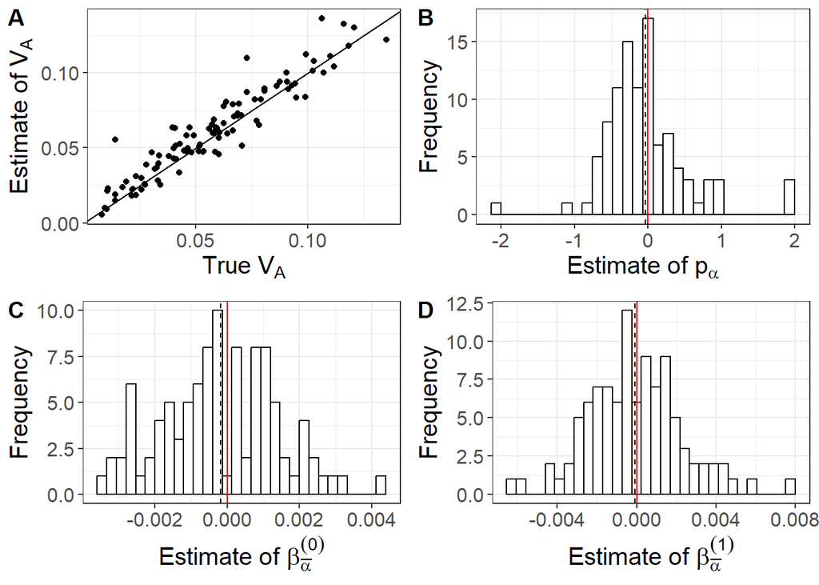

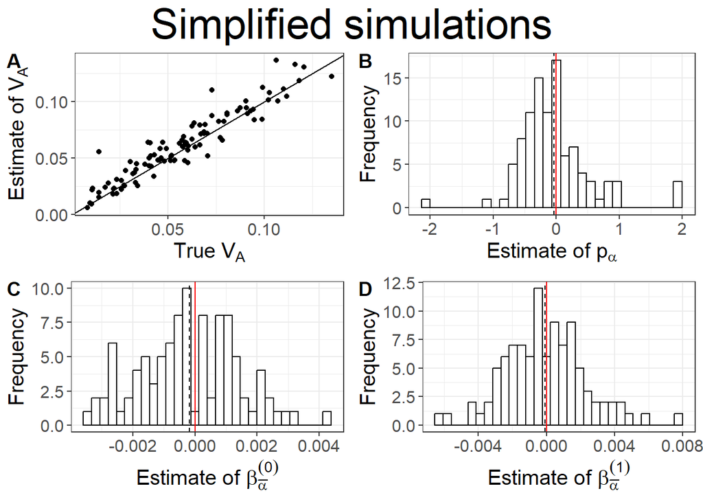

We then vary ml_expt, n_ind_exp, n_cages, and ngen2 one at a time while keeping the other parameters fixed at their standard values.

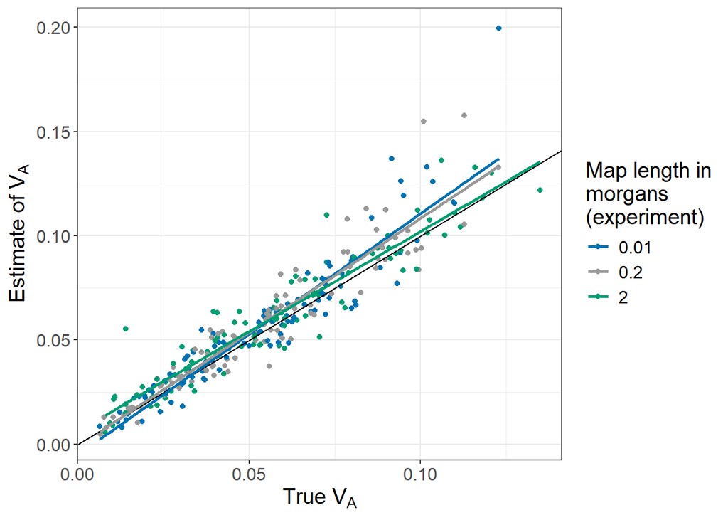

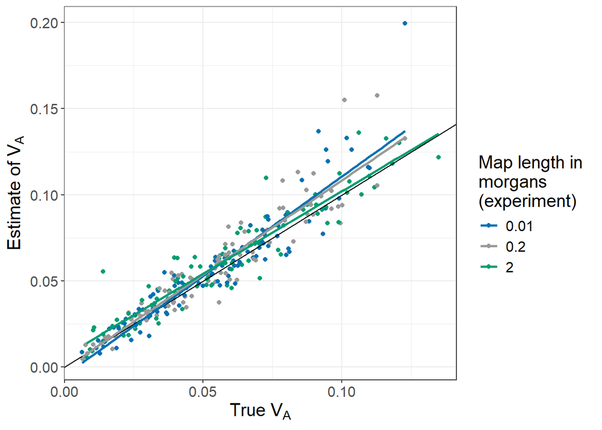

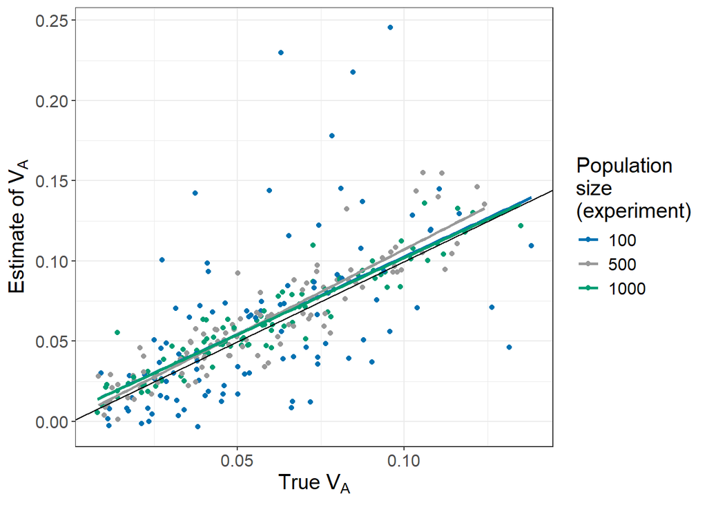

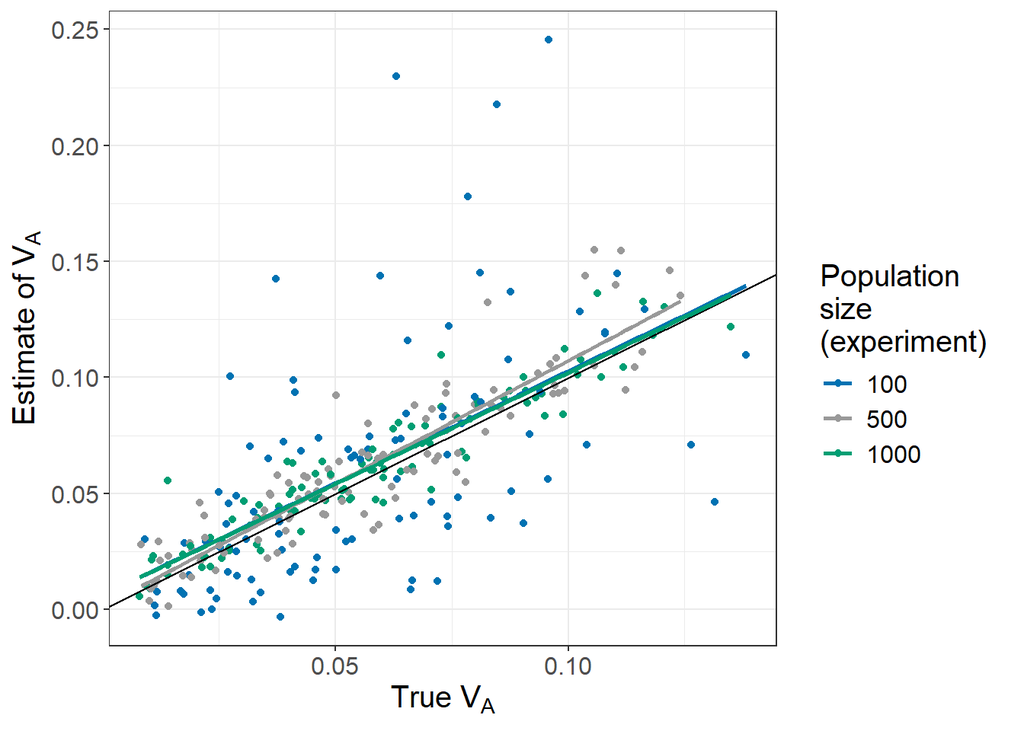

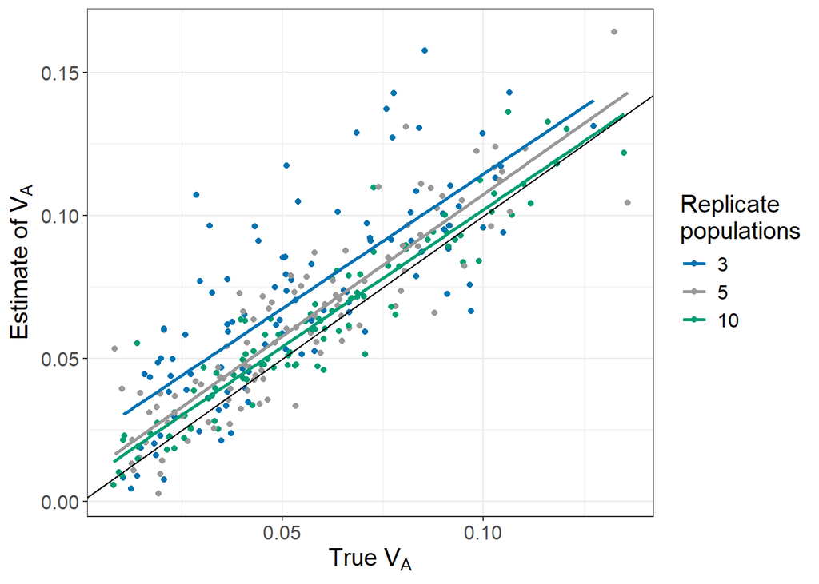

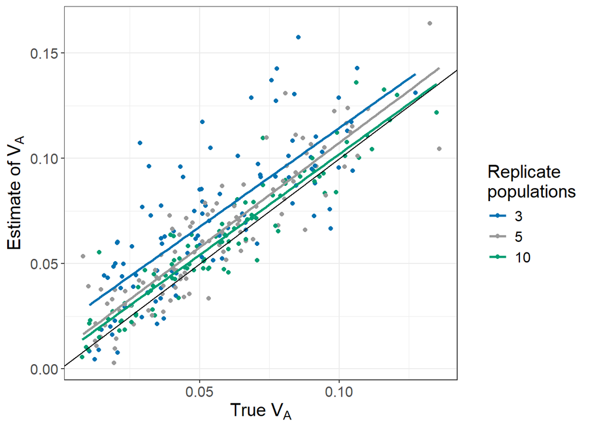

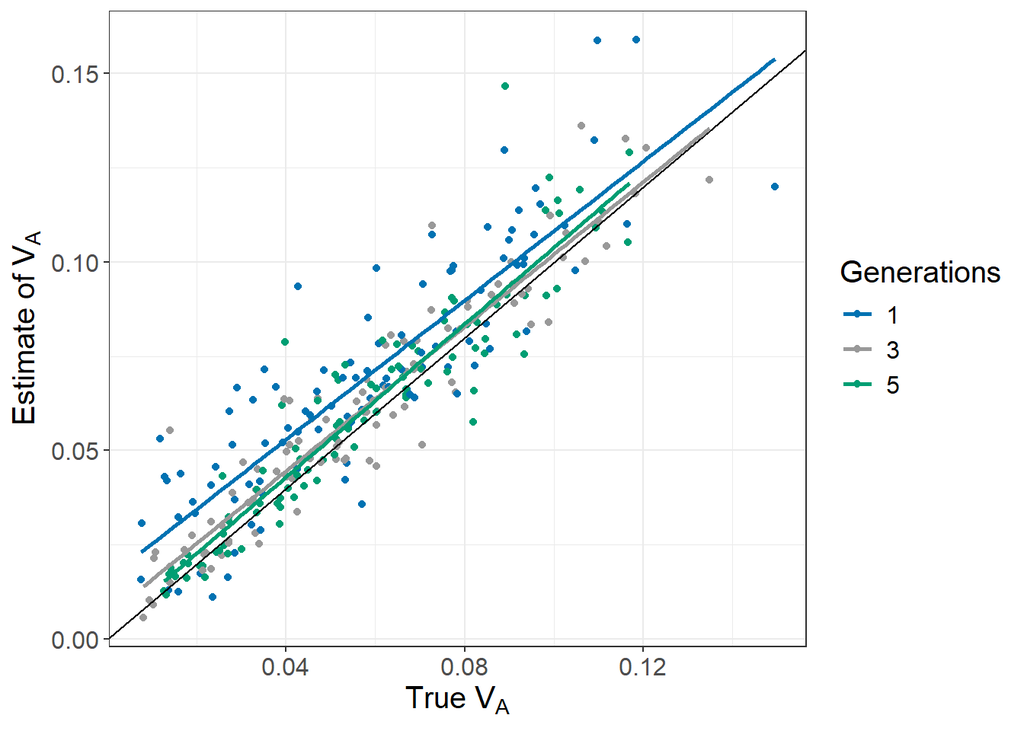

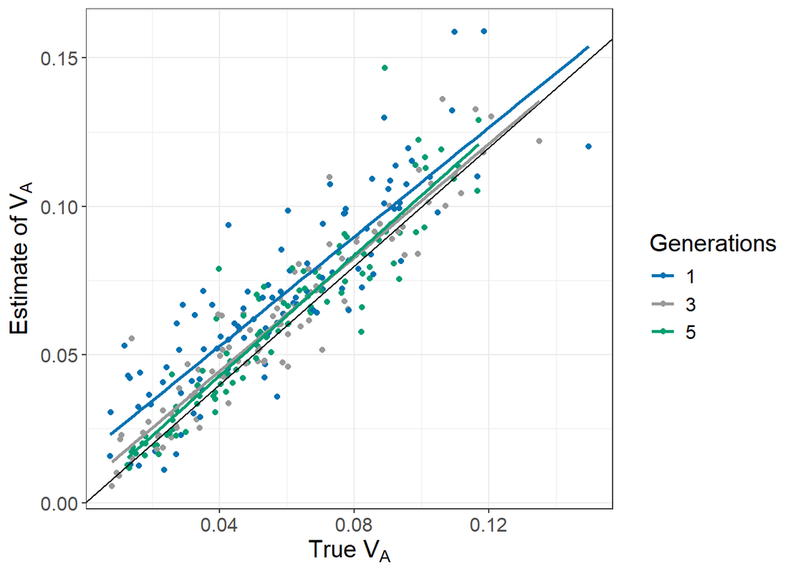

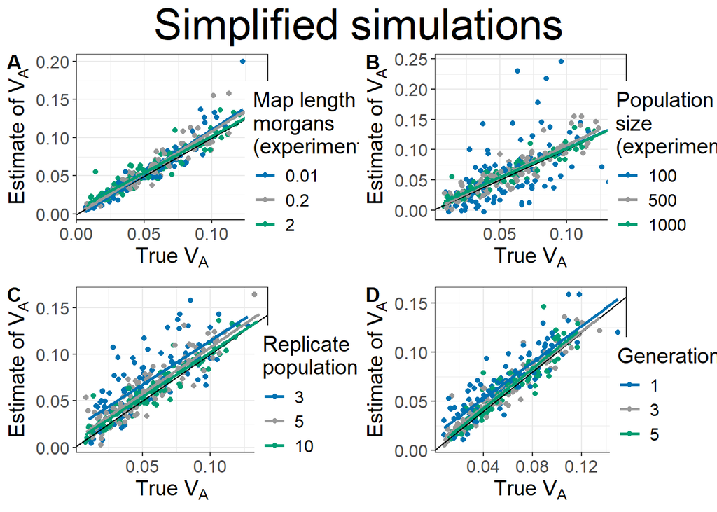

## Full simulations with a burnin phase of 25000 generations

### Set 9 (larger simulations (scale = 0.033): ml = 0.5, ml_exp = 2)

The standard set for full simulations.

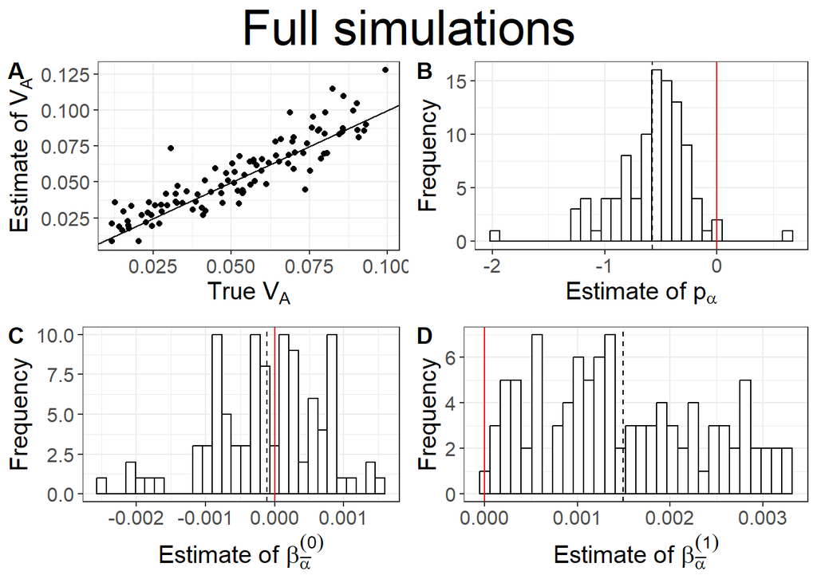

### Set_N1 (scale = 0.045): ml = c (5, 50, 250), ml_exp = 2, mut_ratio = 0

Varying map length in history, but for _{scale} = 0.045

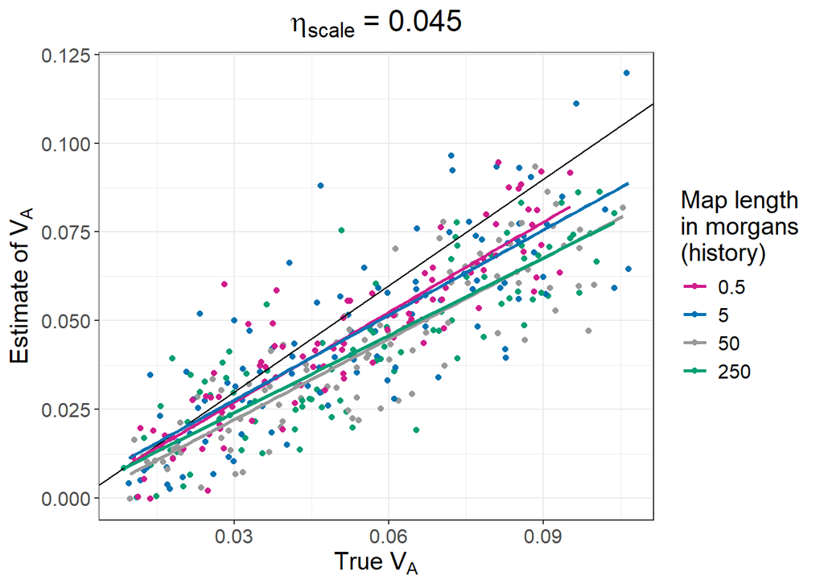

### Varying the ratio of beneficial:deleterious mutations (scale = 0.033)

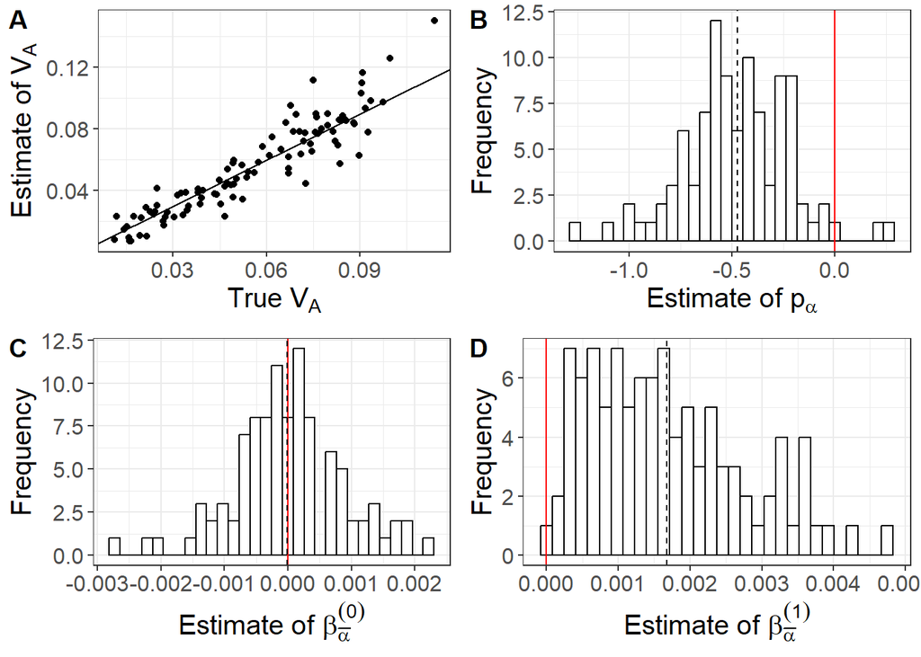

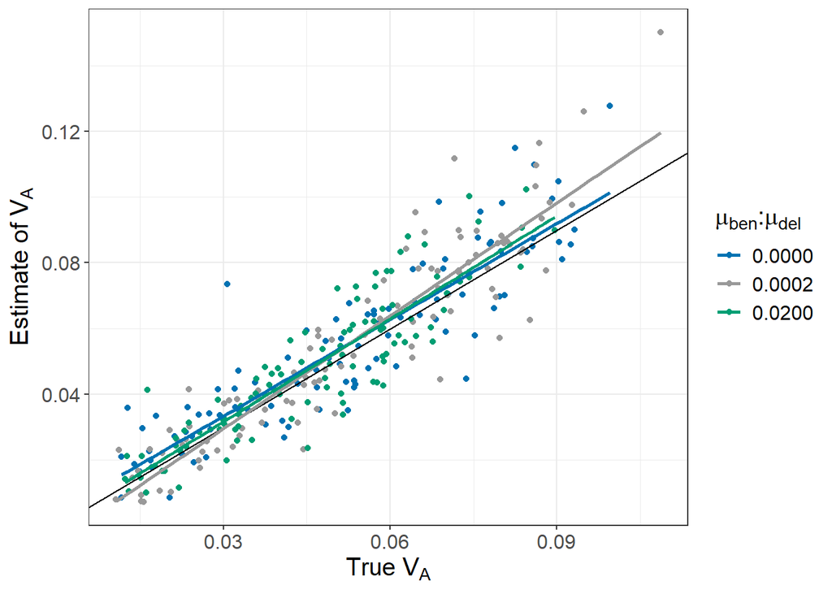

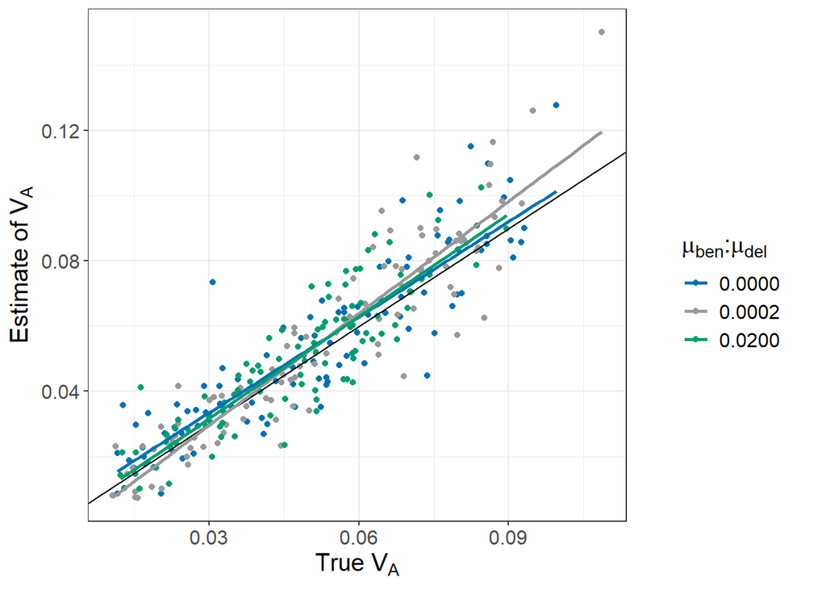

### Set_12 Varyingthe map length in the experiment phase (scale = 0.033): ml_exp = c(0.01, 0.2, 2), mut_ratio = 0

Needs data from set_12 as well as set_9

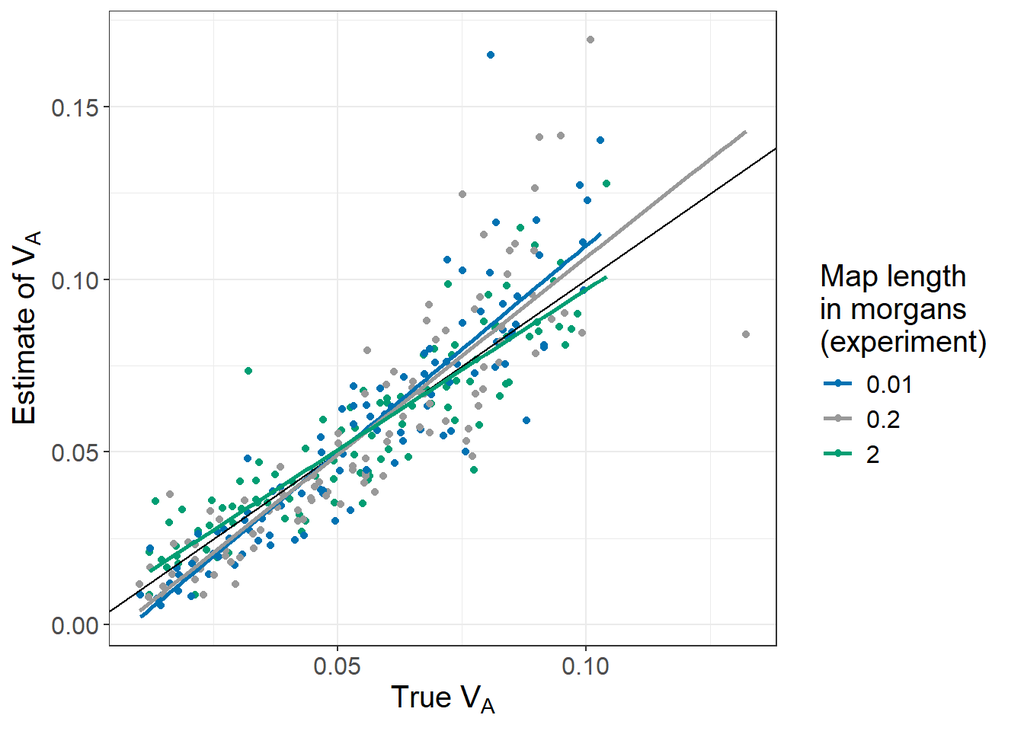

## Simulations with burnin (varying the scale)

Needs datasets for set 7, set 9, and set N1

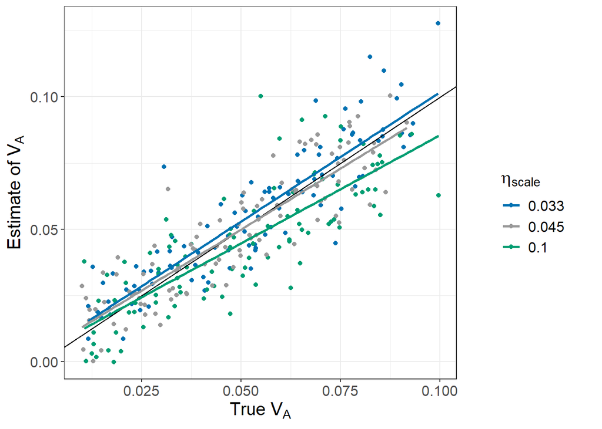

## Simulations with burnin (varying the map length) (scale = 0.033)

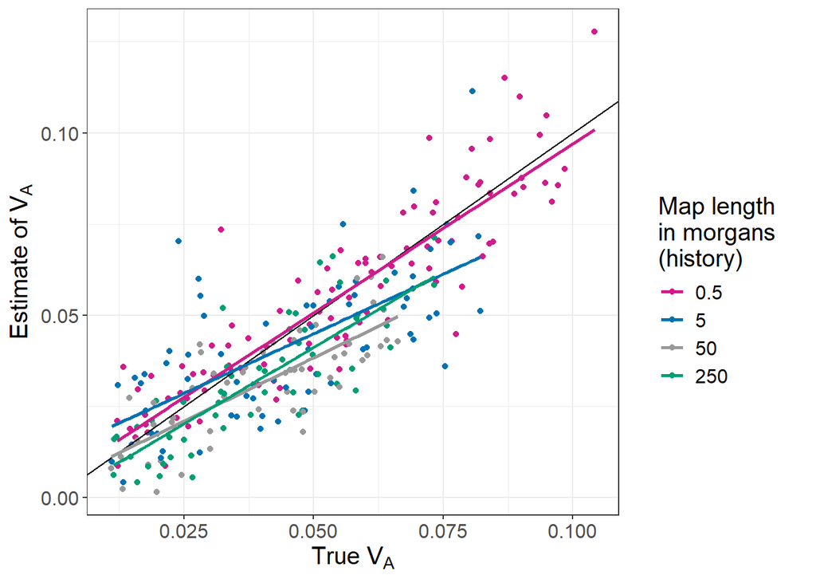

## Simulations with burnin (scale = 0.033) analysed with all.gp = FALSE (standard) or all.gp = TRUE (gametic phase LD not used)

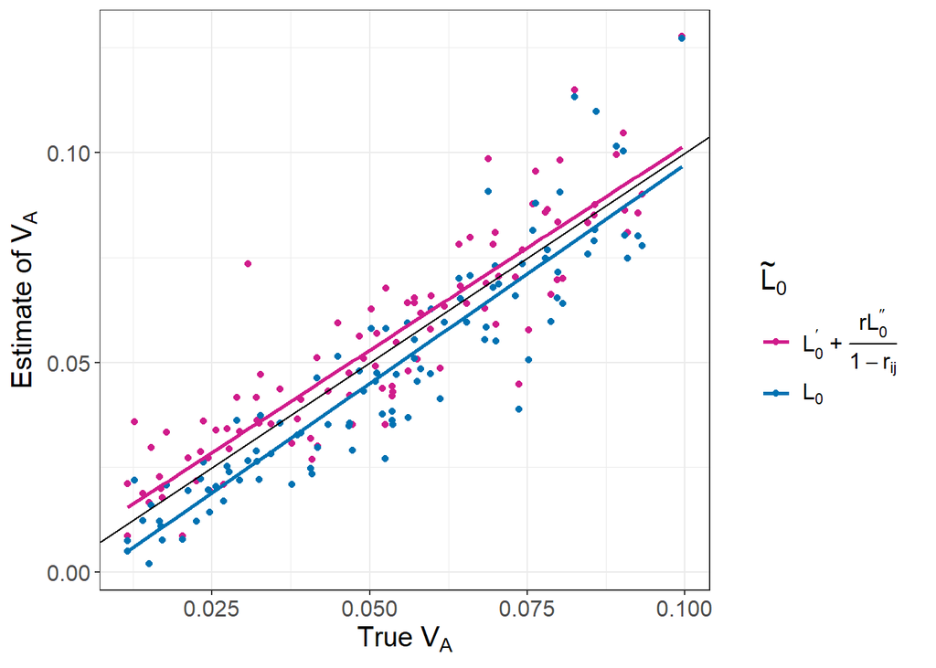

## Simulations with burnin (scale = 0.033) analysed with Ne = nind = 1000

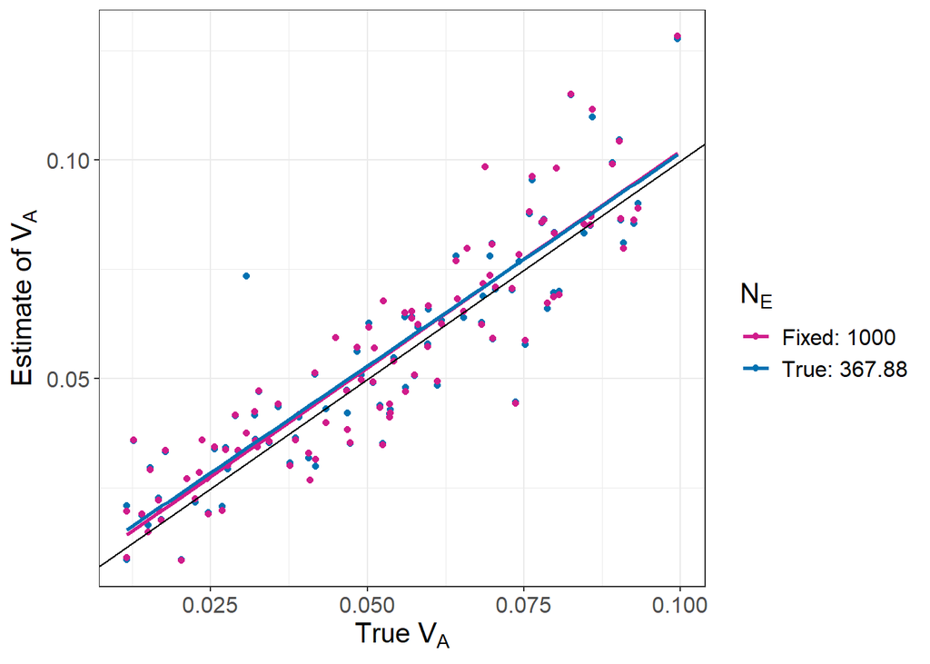

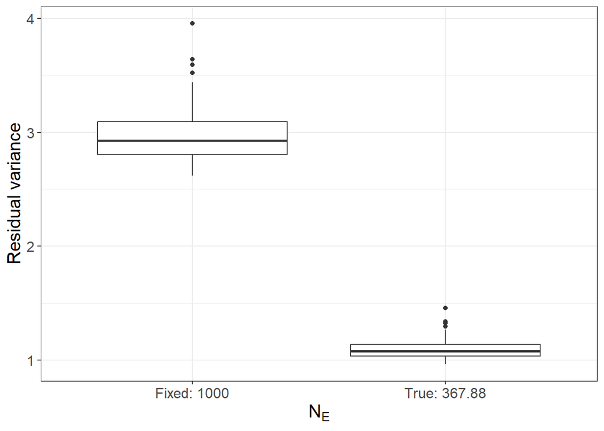

## Combine plots for large (scale = 0.033) simulations with burnin

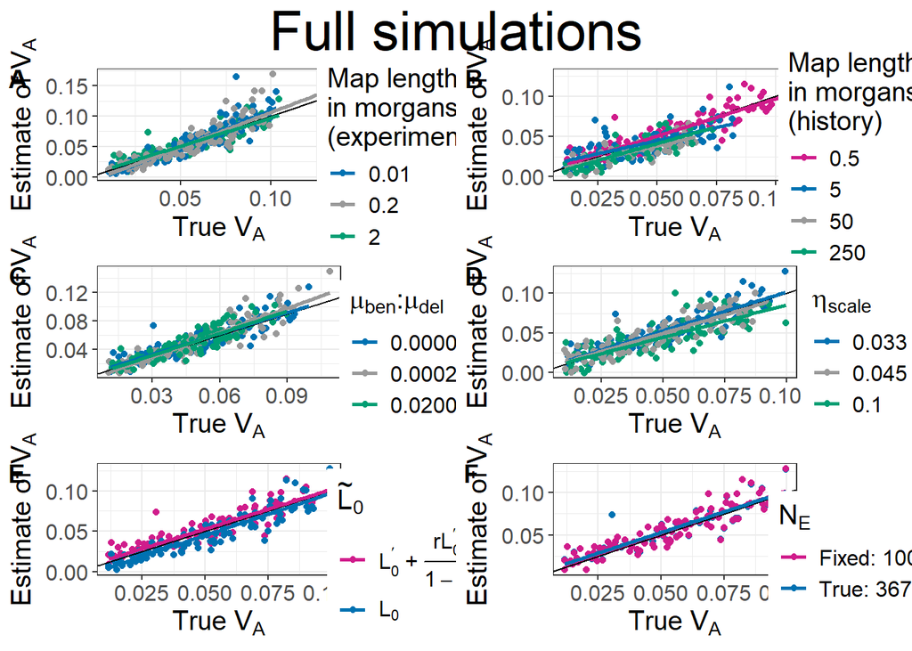

## Additive genic variance lost during the experiment

```
## Simulation with the geratest absolute loss in initial additive genic variance:
```

```
## Simulation with the smallest absolute loss in initial additive genic variance:
```